# Effects of loan features on its APR rate

# Investigation Overview

This research was started with the hopes of exploring the characteristics of loans that could be ussed to predict its APR rate i.e. the effective interest rate charge on loans.

# Dataset Overview

The data set contained 113,937 loans with 81 variables for each loan, including loan amount, borrower rate (or interest rate), current loan status, borrower income, and many others. Variables such as LoanStatus, EmploymentStatus and Term were converted to categorical variables to aid my analysis.

## Distribution of APR Rates

- A loan APR is a more effective rate to consider when comparing loans. It includes not only the interest expense but also all fees and costs involved in procuring the loan.
- The BorrowerAPR feature in the dataset was spread across a wide range from 0.65% at its least to 51%. Initially plotted with a binsize of 2, I couldn't get a good understanding of its distribution. However, the smaller binsize proved to be very insightful. The large spike at about 36% suggested that this is indeed the most common loan APR rate.

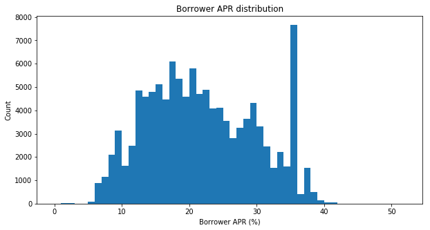

```python
#Investigating further on a smaller bin size
binsize = 1
bins = np.arange(0, APR_perc.max()+binsize, binsize)

plt.figure(figsize=[10, 5])
plt.hist(x = APR_perc, bins = bins)
plt.xlabel('Borrower APR (%)')
plt.ylabel('Count')
plt.title('Borrower APR distribution')
plt.show()
```

## Distribution of Employment Status

- This is the Borrower's working status at the time the loan was listed.
- I plotted this distribution on a horizontal bar chart. The proportion of each status amongst the total is also displayed next to their respective bars. Most Prosper Loan's borrowers are employed and thats about 59% of all the borrowers.

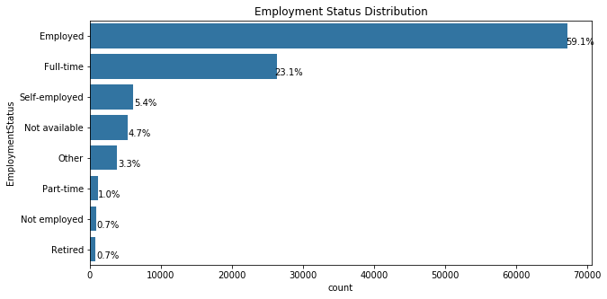

```python
base_color = sb.color_palette()[0]
cat_order = prosper_clean['EmploymentStatus'].value_counts().index
plt.figure(figsize=[10, 5])
sb.countplot(data=prosper_clean,y='EmploymentStatus',color=base_color, order=cat_order);
plt.title('Employment Status Distribution')

# add annotations
n_points = prosper_clean.shape[0]
cat_counts = prosper_clean['EmploymentStatus'].value_counts()
locs, labels = plt.yticks() # get the current tick locations and labels

# loop through each pair of locations and labels
for loc, label in zip(locs, labels):

    # get the text property for the label to get the correct count
    count = cat_counts[label.get_text()]
    pct_string = '{:0.01f}%'.format(100*count/n_points)

    # print the annotation just below the top of the bar
    plt.text(count+1700, loc+0.3,  pct_string, ha = 'center', color = 'black');
```

## Distribution of Prosper Score

- This is a custom risk score built using historical Prosper data.
- I plotted this using a standard bar chart. The most common Prosper scores for prosper loans are 4, 6 and 8.

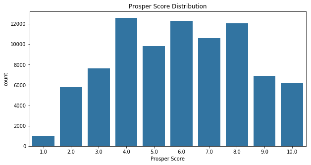

```python
base_color = sb.color_palette()[0]
plt.figure(figsize=[10, 5])
sb.countplot(data=prosper_clean,x='ProsperScore',color=base_color)
plt.xlabel('Prosper Score')
plt.title('Prosper Score Distribution');
```

## Distribution of Listing Category

- This is the category of the listing that the borrower selected when posting their listing.
- The listing categories are ordered by frequency and the proportion of each category amongst the total is displayed next to the respective bars. Most of the listings on Prosper loans are for debt consolidations comprising of about 51% of the total listings. This means that more than half the loans are being taken out to pay off debts and liabilities.

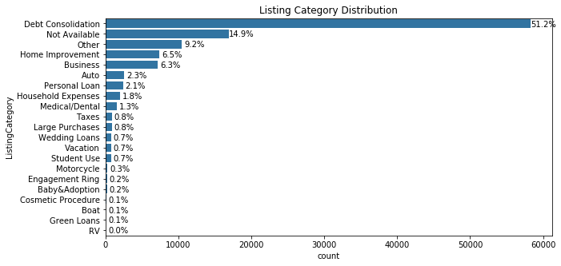

```python
cat_order = prosper_clean['ListingCategory'].value_counts().index
plt.figure(figsize=[10, 5])
sb.countplot(data=prosper_clean,y='ListingCategory',color=base_color, order=cat_order);
plt.title('Listing Category Distribution')

# add annotations
n_points = prosper_clean.shape[0]
cat_counts = prosper_clean['ListingCategory'].value_counts()
locs, labels = plt.yticks() # get the current tick locations and labels

# loop through each pair of locations and labels
for loc, label in zip(locs, labels):

    # get the text property for the label to get the correct count
    count = cat_counts[label.get_text()]
    pct_string = '{:0.01f}%'.format(100*count/n_points)

    # print the annotation just below the top of the bar
    plt.text(count+1700, loc+0.3,  pct_string, ha = 'center', color = 'black');
```

# Which loan features have a significant impact on the APR?

## BorrowerAPR VS EmploymentStatus

- I used a box plot to clearly show the relationship between both features.
- Loans borrowed by those receiving some form of income (i.e Employed, Full-time, Other, Part-time, Retired and Self-employed) have a lower interest rate compared to borrowers who are not employed they're more likely to pay back compared to the loans borrowed by those who are unemployed.
- The interest rates for those who are self-employed were also higher compared to those in full-time jobs due to job security.

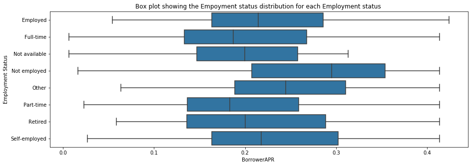

```python
plt.figure(figsize = [15, 5])
sb.boxplot(data=prosper_clean,x='BorrowerAPR', y='EmploymentStatus',color=base_color);
plt.xlabel('BorrowerAPR ');
plt.ylabel('Employment Status');
plt.title("Box plot showing the Empoyment status distribution for each Employment status ")
plt.show();
```